# Project 4 – Red Wine Quality Dataset Exploration by Mark Cassar

```
## [1] -0.05147378
```

```
## [1] 1.614259
```

total.sulfur.dioxide original correlation, new, and percentage change is

```
## [1] -0.1851003
```

```
## [1] -0.1841918
```

```
## [1] -0.49081
```

and the original correlation, new, and change for the SO2.ratio is

```
## [1] 0.1941134
```

```
## [1] 0.1933579
```

```
## [1] -0.3891738
```

No strong connections coming from the SO2 values.

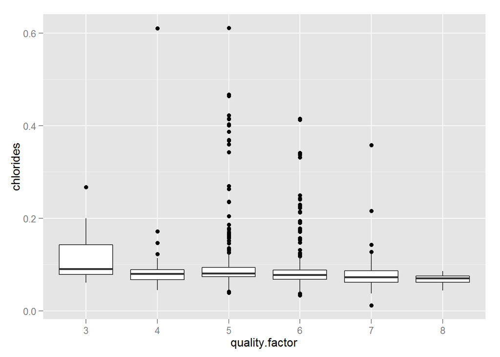

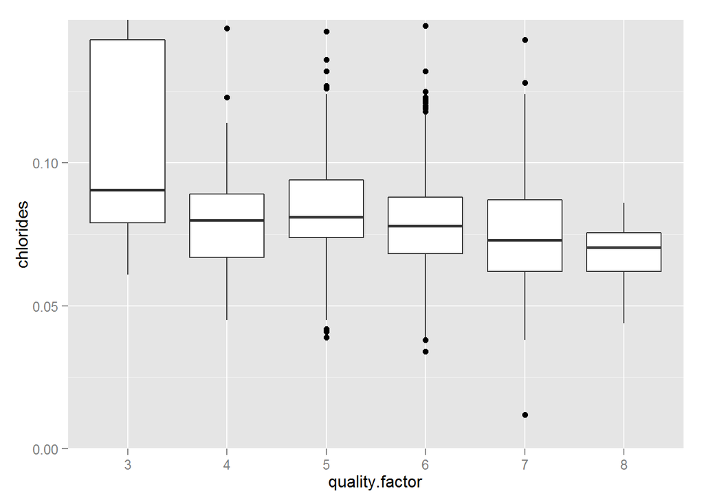

Showing a slight downward trend.And a pretty large interquartile rangefor a quality rating of 3 compared to all other quality ratings. The IQR’s for the 3’s, 5’s, and 8’s are

```
## [1] 0.064
```

```
## [1] 0.02
```

```
## [1] 0.0135
```

And the correlation value is

```
## [1] -0.1289066
```

showing but a slight negative correlation as noted earlier.

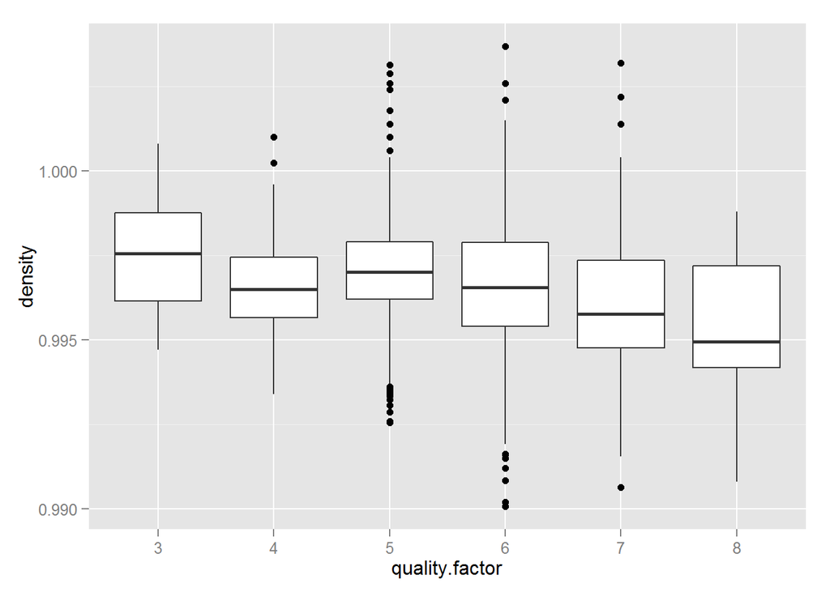

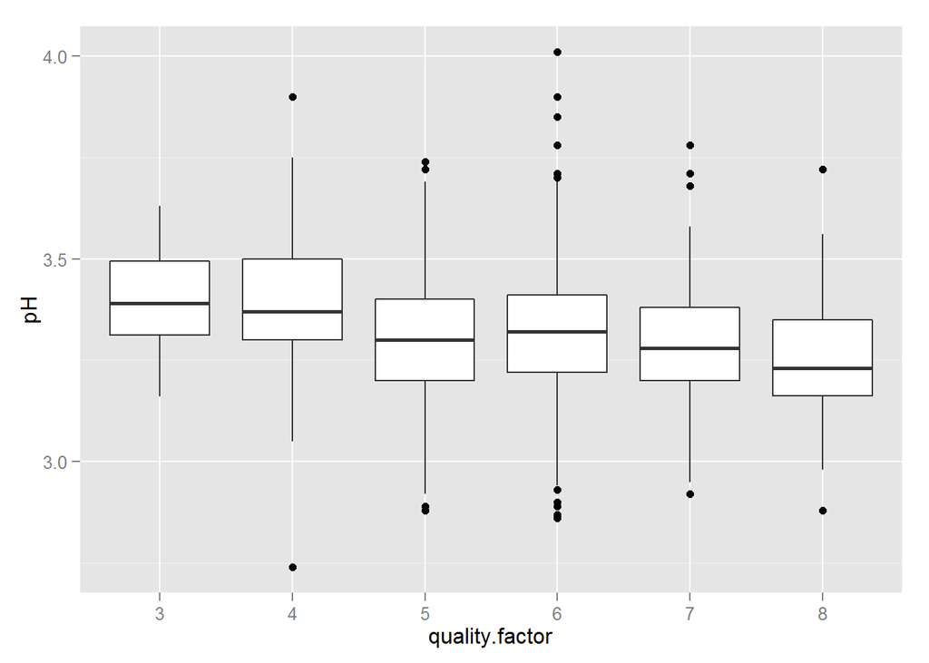

Density and pH show similar trend in connection with quality to that exhibited by chlorides. Let’s check the correlations to confirm.

```
## [1] -0.1749192
```

```
## [1] -0.05773139
```

So both show slight negative correlation with density being a bit stronger than chlorides and pH being weaker.

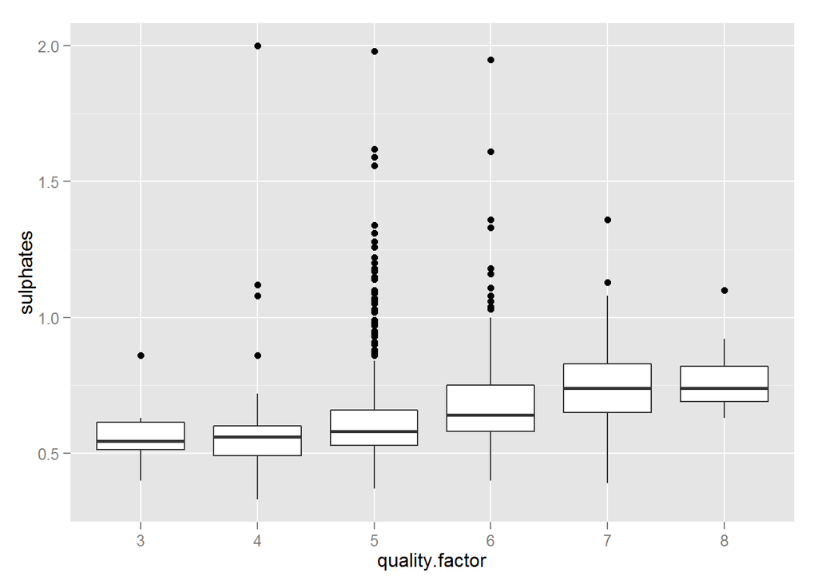

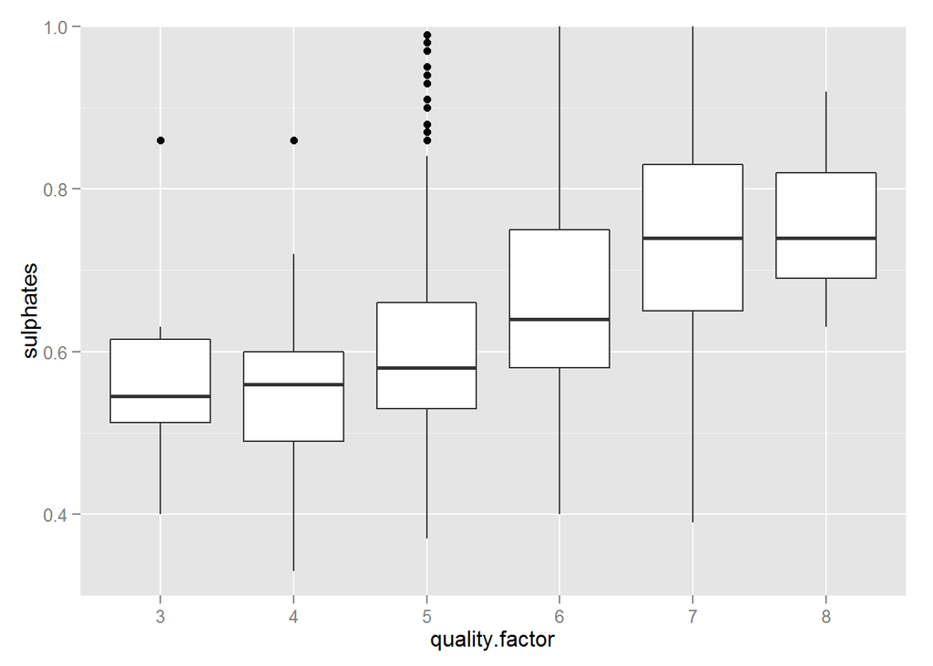

Sulphates seem to correlate well with quality.

```
## [1] 0.2513971
```

But it is not as strong as volatile acidity.

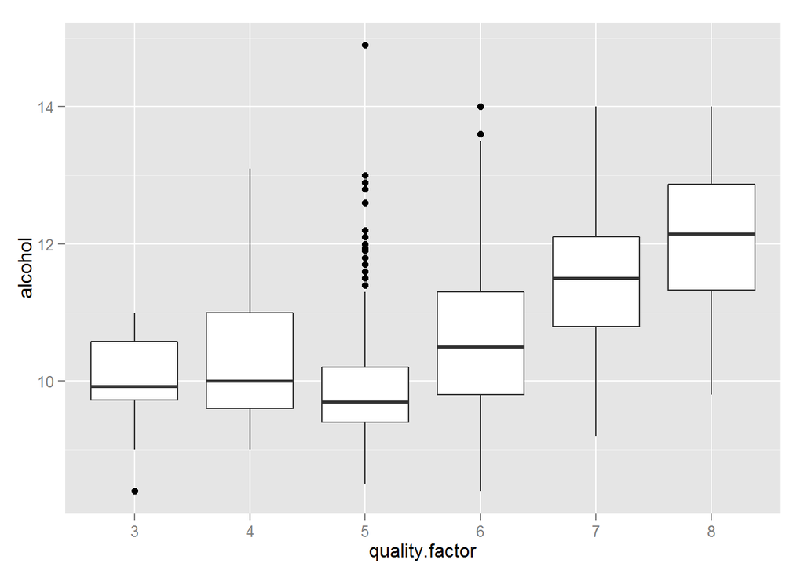

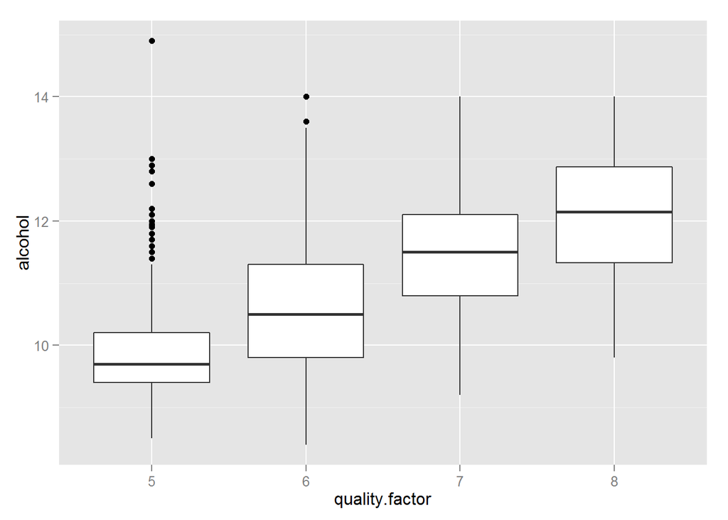

Correlation with percentage of alcohol looks quite strong:

```
## [1] 0.4761663
```

and even stronger if we ignore quality scores of 3 and 4:

```
## [1] 0.5218858
```

I’ll now summarize the correlations with quality, ordered by absolute value.

| Variable | Correlation |
| --- | --- |
| alcohol | 0.4762 |
| volatile.acidity | -0.3906 |
| inverse.v.acidity | 0.3637 |
| acidity.ratio | 0.3435 |
| sulphates | 0.2514 |
| citric.acid | 0.2264 |
| SO2.ratio | 0.1941 |
| total.sulfur.dioxide | -0.1851 |
| density | -0.1749 |
| chlorides | -0.1289 |
| fixed.acidity | 0.1241 |
| pH | -0.05773 |
| free.sulfur.dioxide | -0.05066 |
| residual.sugar | 0.01373 |

I think that I’ll draw the line at a correlation with an absolute value greater than 0.2. Also, given that volatile acidity, its inverse, and the acidity ratio represent the same or very similar characteristics, I will only use one of them. Thus, I am looking at alcohol, volatile acidity, sulphates, and citric acid as the main variables correlated with quality.

Now I’ll retrace my steps and look at inter-variable correlations.

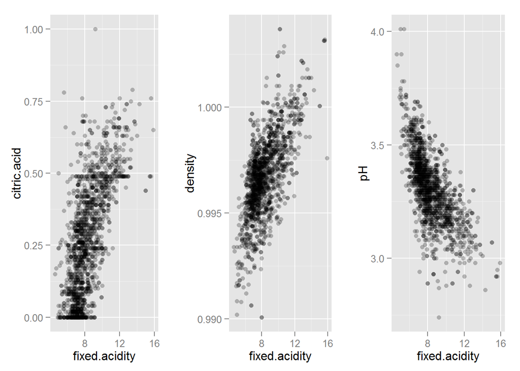

There is nothing surprising here. Citric acid is one of the fixed acids in wine so it makes sense that both are positively correlated. Fixed acidity correlating with density seems logical as the acids will be higher in density than the bulk of water/alcohol in the wine so density should naturally increase with the level of fixed acidity. pH is a scaled logarithmic measure of acidity with lower pH corresponding to higher levels of acidity, hence the negative correlation.

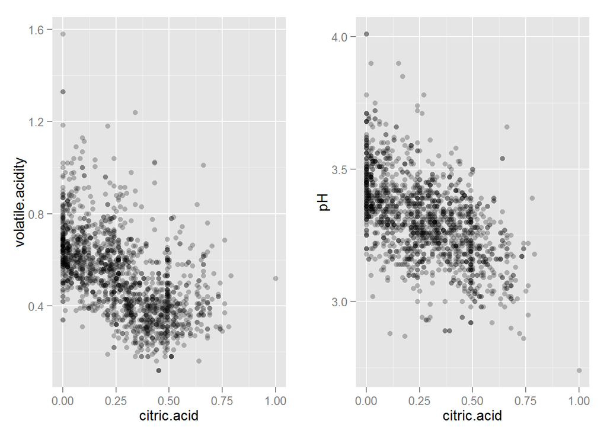

These relations are not a strong as the first 3, as the correlation coefficients suggest. We see again the expected inverse relation between pH and an acid, this time citric acid. Not sure what the relationship between volatile acid (which I understand to be from acetic acid in the wine) and citric acid. Perhaps as the fixed acidiy increases (of which citric acid is one component) the volatile acidity is naturally reduced. That is somewhat supported by the fact that the correlation between fixed and volatile acidity is about -0.25.

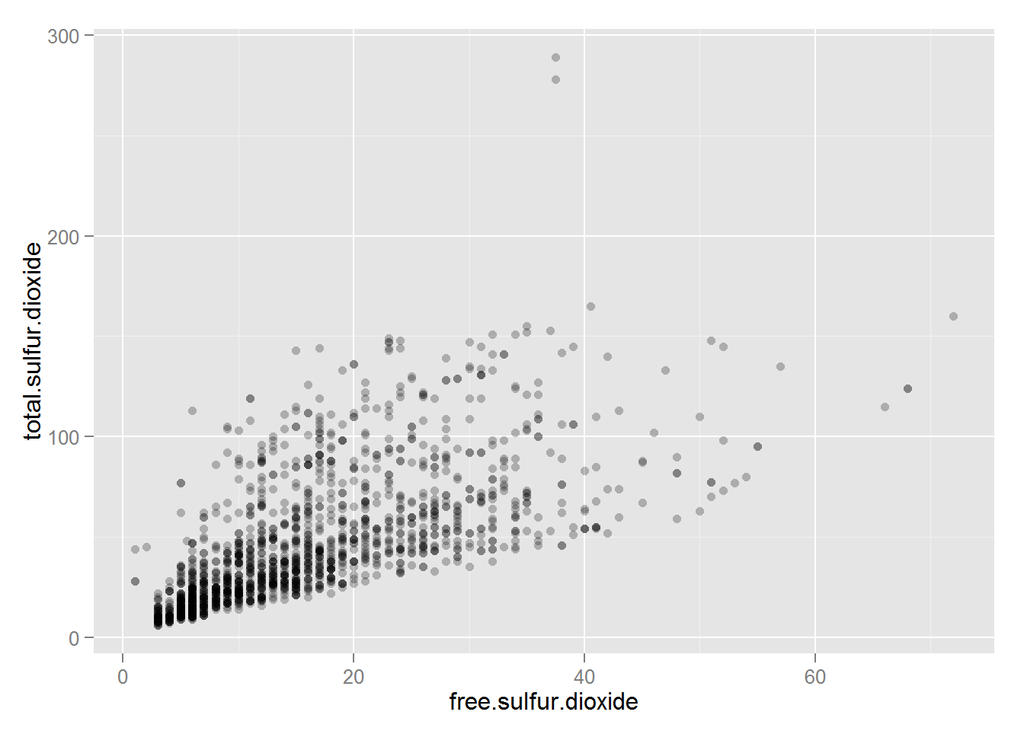

The relationship between free and total SO2 makes sense as one would expect the total amount of SO2 to increase as the amount of free SO2 did. The variance seems to increase as free SO2 increases and there is a banding effect suggesting free SO2 takes on only certain values.

```
##
##    1    2    3    4    5  5.5    6    7    8    9   10   11   12   13   14
##    3    1   49   41  104    1  138   71   56   62   79   59   75   57   50
##   15   16   17   18   19   20   21   22   23   24   25   26   27   28   29
##   78   61   60   46   39   30   41   22   32   34   24   32   29   23   23
##   30   31   32   33   34   35   36   37 37.5   38   39   40 40.5   41   42
##   16   20   22   11   18   15   11    3    2    9    5    6    1    7    3
##   43   45   46   47   48   50   51   52   53   54   55   57   66   68   72
##    3    3    1    1    4    2    4    3    1    1    2    1    1    2    1
```

# Bivariate Analysis

### Talk about some of the relationships you observed in this part of the investigation. How did the feature(s) of interest vary with other features in the dataset?

Quality seems to correlate with alcohol, volatile acidity, sulphates, and citric acid in a linear fashion, while there seems to be some non-linear correlation with free and total sulfur dioxide.

### Did you observe any interesting relationships between the other features (not the main feature(s) of interest)?

Of the strongest realtions:

Fixed acidity correlates postively with citric acid and density and negatively with pH.

Citric acid also correlates with both volatile acidity and pH, in a negative fashion.

Free sulfur dioxide correlates positively with total sulfur dioxide, as I would have expected.

### What was the strongest relationship you found?

Quality is most strongly connected to alcohol content of the wine.

# Multivariate Plots Section

I will create a quality label based on the quality score:

- ‘Bad’ = 1,2,3,4
- ‘Ok’ = 5
- ‘Good’ = 6
- ‘Very Good’ = 7,8,9,10

And now I will explore in a bit more depth some of the relations discovered in the bivariate analysis.

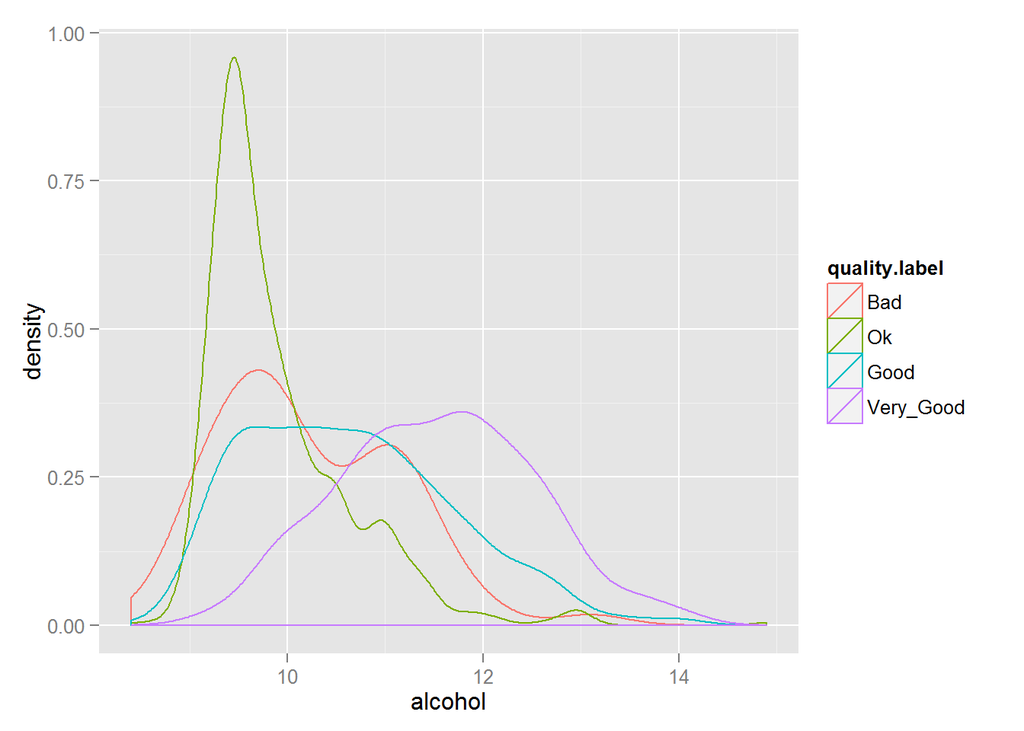

I found that alcohol had the strongest correlation with quality and this graph starts to show a bit more detail about that relation. “Bad” and “Ok” wines clearly dominate at alcohol percentages of 10 and below while “Very_Good” wines tend to dominate at alcohol levels above about 11.5%. The in-between range is mixed and “Bad” wines show an interesting bimodal shape with peaks just below 10% and just above 11%.

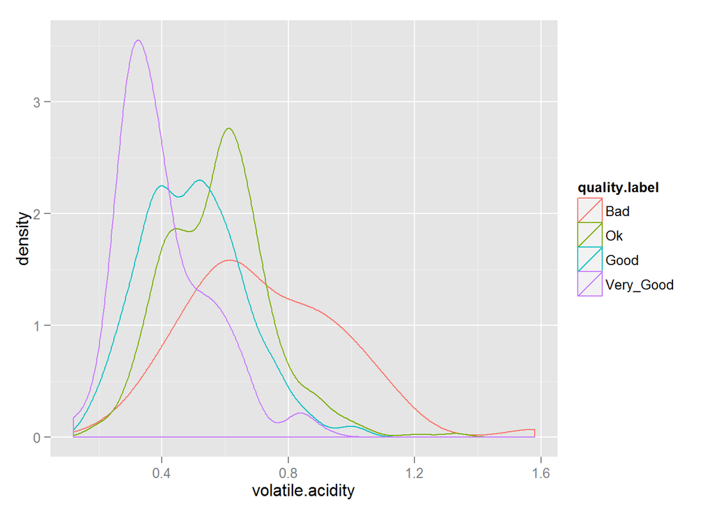

The second strongest correlation with quality was exhibited by volatile acidity. The above density plot shows the inverse relationship I saw earlier with “Very_Good” and “Good” wines dominating at levels of 0.4 and below and “Ok” and “Bad” wines dominating at levels of 0.8 and above.

Let me see what the other two strongest correlations can show me, sulphates and citric acid:

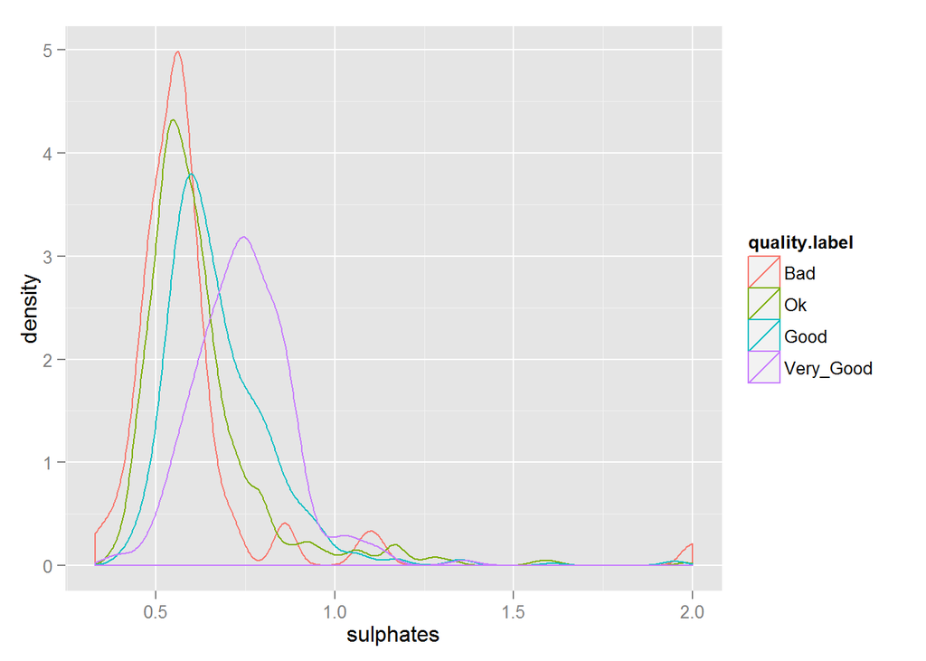

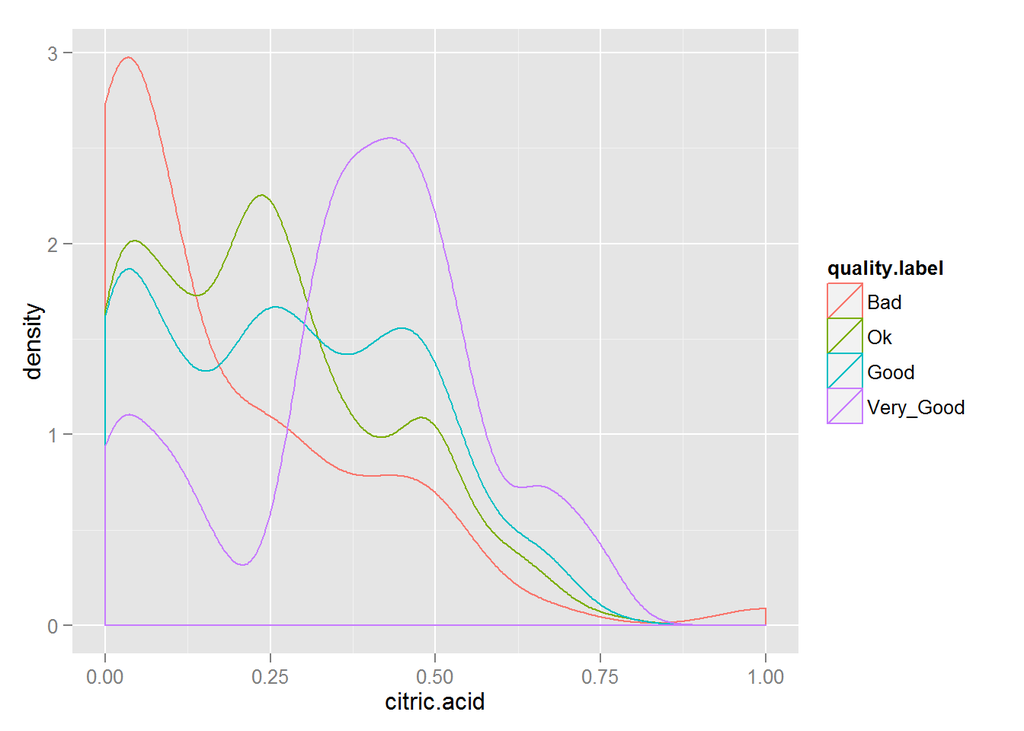

Density plots for sulphates and citric acid show the weaker correlation with quality.

Sulphates shows a fairly well separated peak for “Very Good” wines at a value of about 0.7, though below that value there seems to be a pretty equal mix of “Bad”, “Ok”, and “Good” wines.

The citric acid plot has a more interesting multimodal shape with “Bad” wines more prevalent below values of 0.125 and “Very_Good” wines more prevalent at values between about 0.3 and 0.5.

Perhaps mixing the 4 features will give stronger separation of the 4 wine labels?

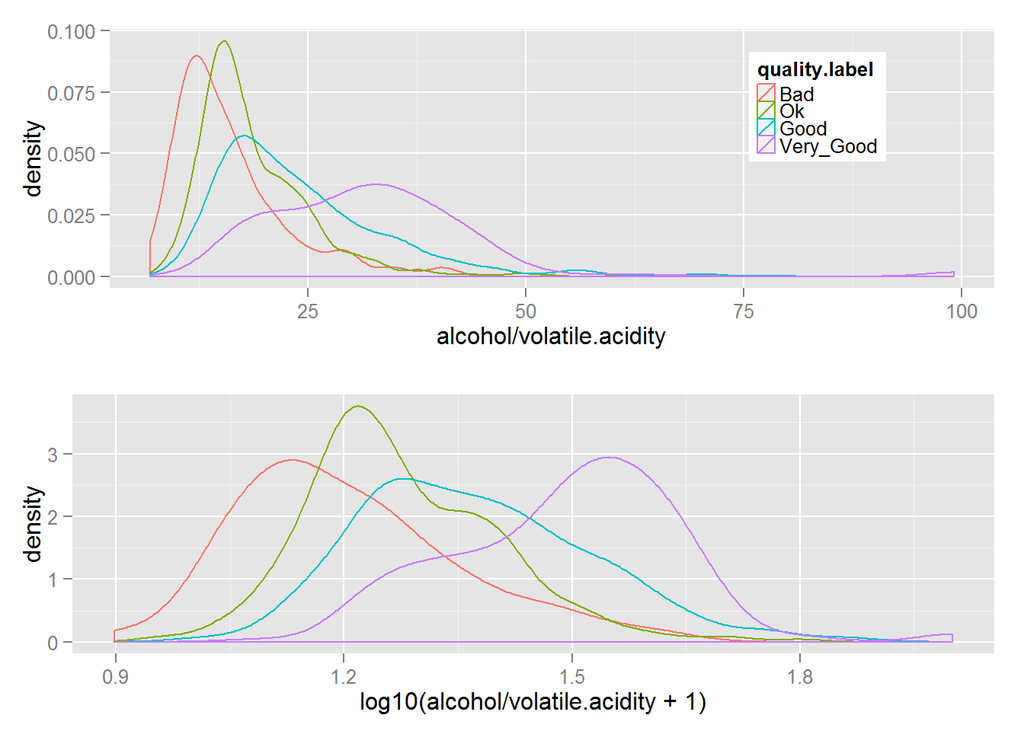

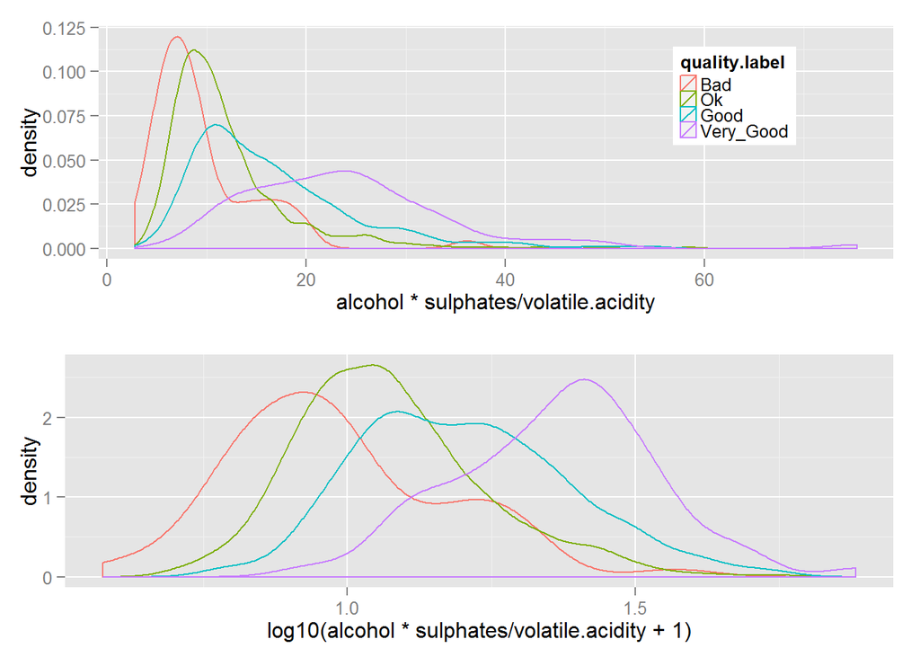

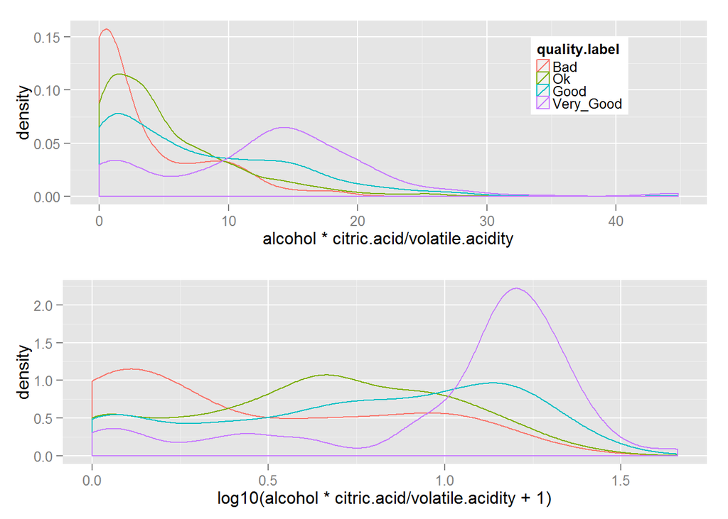

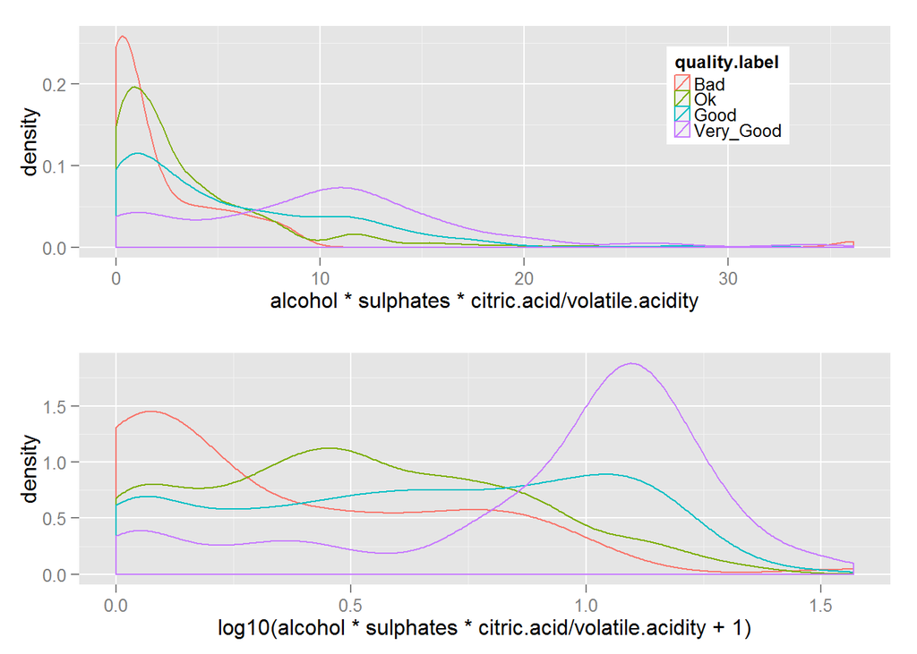

Now I want to look at relationship between the variables that correlate well with quality.

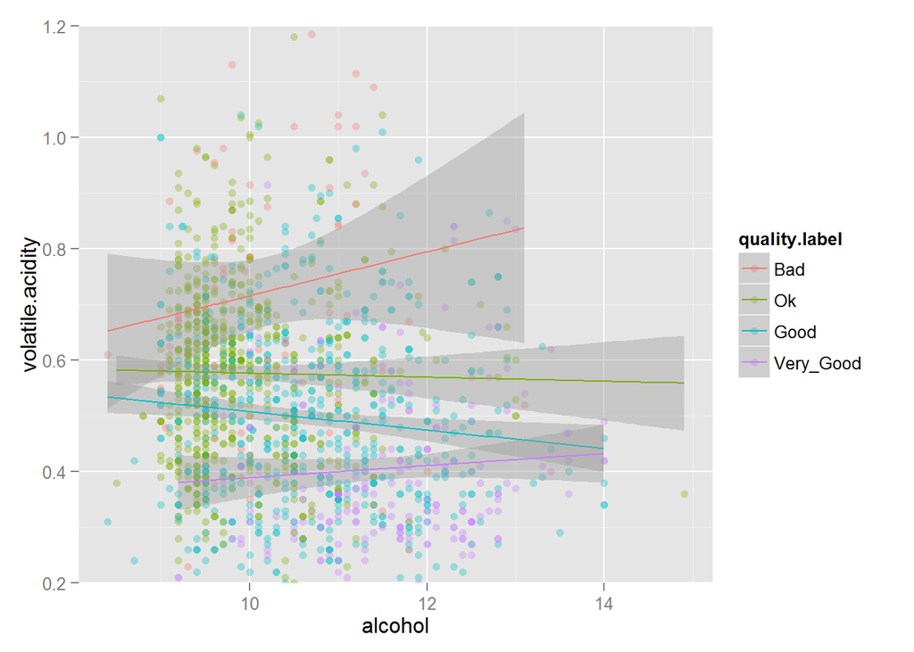

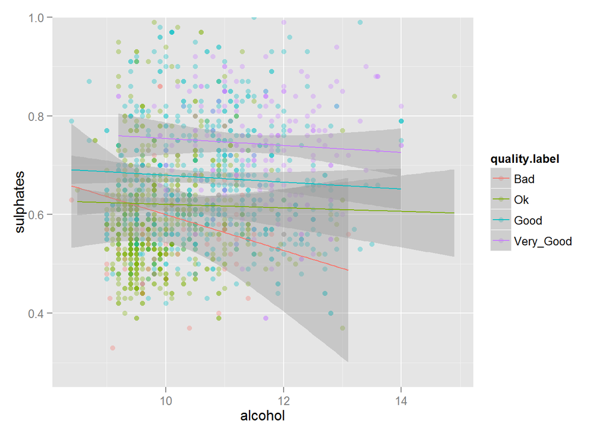

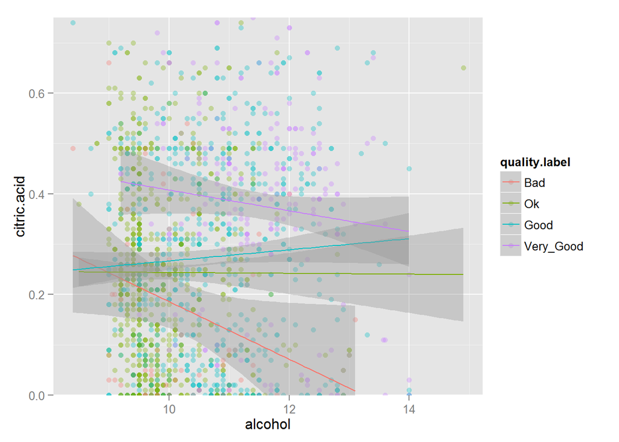

Here, with the help of the regression lines, we can at least see an ordering from “Bad” to “Very_Good” in all 3 charts, top to bottom (along y axis) for the variables with negative correlation and bottom to top for those with positive correlation, as one would expect. Also seeing again that the separation between “Bad” and “Very_Good” is much clearer (greater distance between regression lines and slopes farther from 0) than that between “Ok” and “Good”.

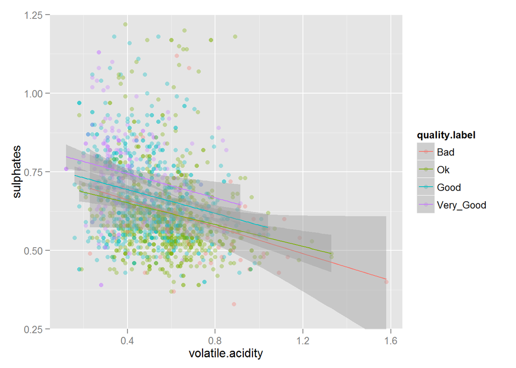

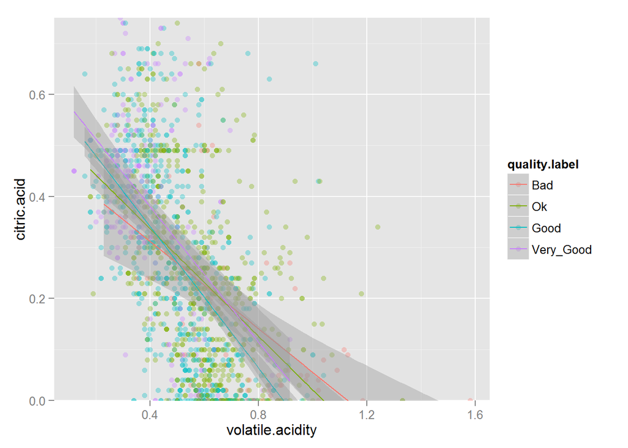

These two charts show some separation but regression lines much more closely aligned and in the second the ordering starts to get lost.

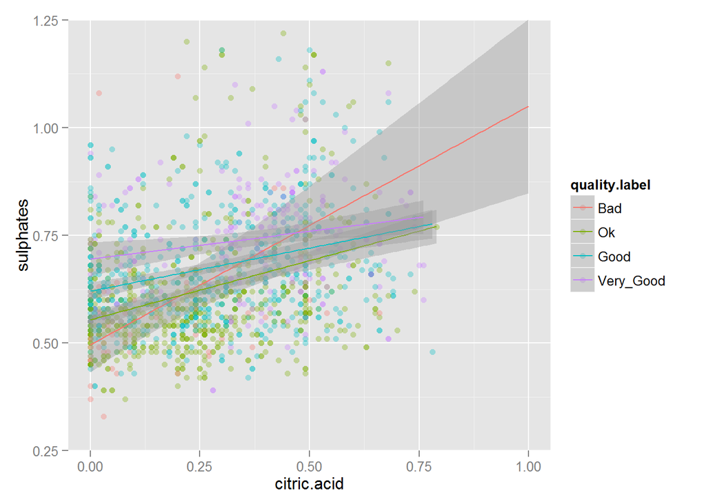

Ordering again gets mixed up with “Bad” wines showing strongest change as citric acid values increase.

Based on what I am seeing, I want to see if I can at least see a clear separation betwee ‘Bad’ and ‘Very Good’ wines.

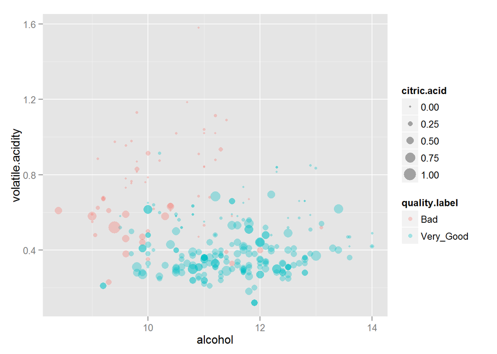

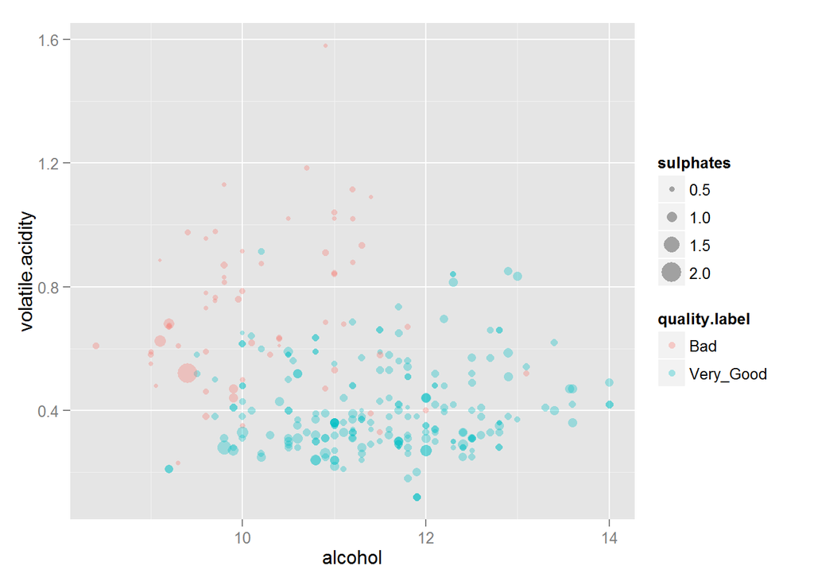

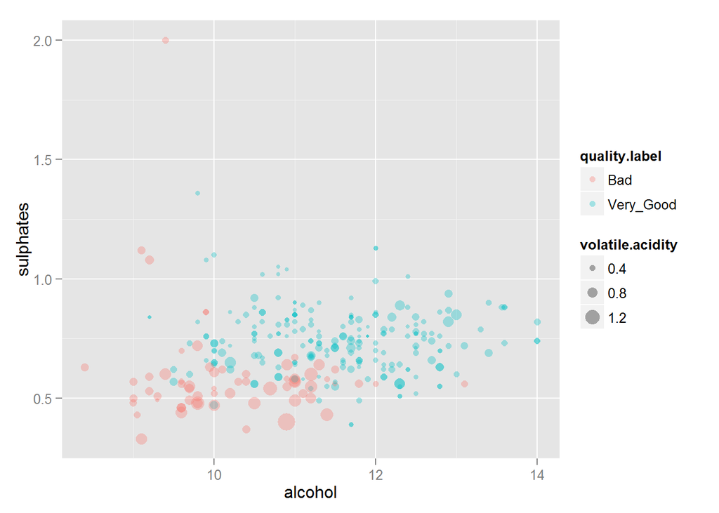

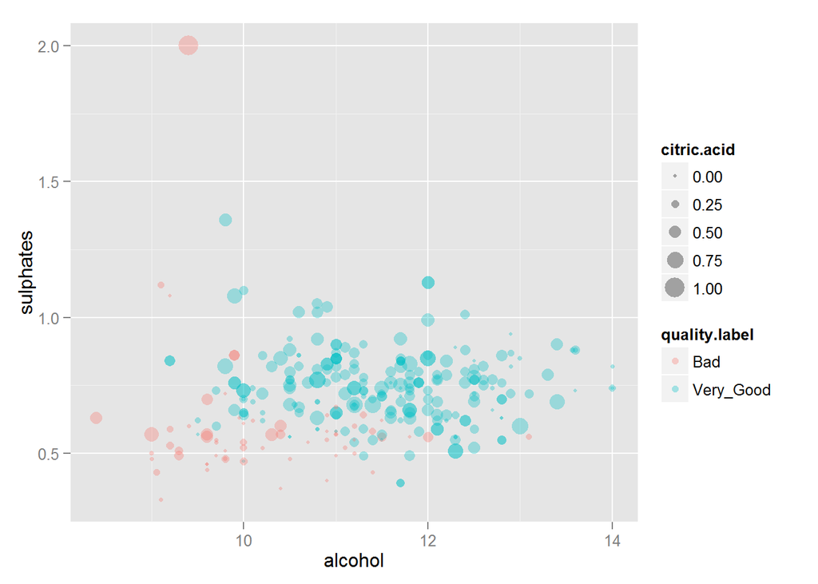

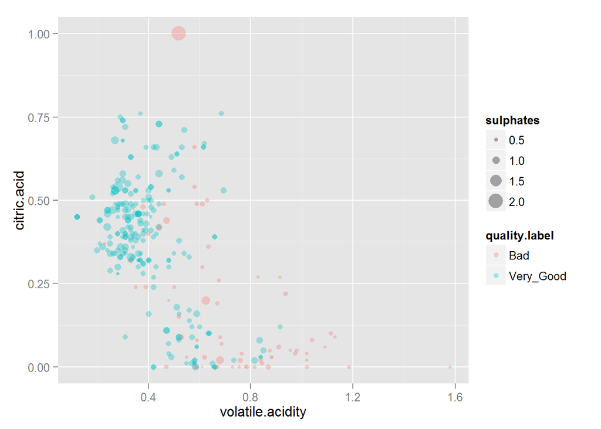

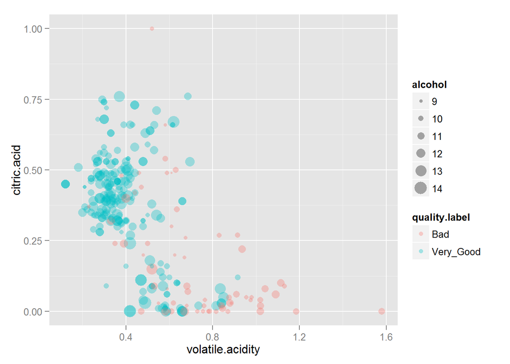

The last plot is starting to show that there may be some decent decision boundaries that do a decent job of separating the ‘very good’ from the ‘bad’. Doing an initial split on citric acid values of 0.25 and higher for “Very_Good” wines gives about 90% accuracy for that branch:

```
## [1] 0.9047619
```

Let’s now look at creating a model.

```
##
## Calls:
## m1: lm(formula = quality ~ alcohol, data = wine)
## m2: lm(formula = quality ~ alcohol + volatile.acidity, data = wine)
## m3: lm(formula = quality ~ alcohol + volatile.acidity + sulphates,
##     data = wine)
## m4: lm(formula = quality ~ alcohol + volatile.acidity + sulphates +
##     SO2.ratio, data = wine)
## m5: lm(formula = quality ~ alcohol + volatile.acidity + sulphates +
##     SO2.ratio + chlorides, data = wine)
## m6: lm(formula = quality ~ alcohol + volatile.acidity + sulphates +
##     SO2.ratio + chlorides + pH, data = wine)
##
## =============================================================================
##                      m1        m2        m3        m4        m5        m6
## -----------------------------------------------------------------------------
## (Intercept)        1.875***  3.095***  2.611***  2.588***  2.749***  4.192***
##                   (0.175)   (0.184)   (0.196)   (0.195)   (0.198)   (0.398)
## alcohol            0.361***  0.314***  0.309***  0.294***  0.278***  0.292***
##                   (0.017)   (0.016)   (0.016)   (0.016)   (0.017)   (0.017)
## volatile.acidity            -1.384*** -1.221*** -1.209*** -1.157*** -1.040***
##                             (0.095)   (0.097)   (0.097)   (0.097)   (0.101)
## sulphates                              0.679***  0.695***  0.882***  0.853***
##                                       (0.101)   (0.100)   (0.110)   (0.110)
## SO2.ratio                                        0.420***  0.403***  0.469***
##                                                 (0.109)   (0.109)   (0.110)
## chlorides                                                 -1.588*** -1.912***
##                                                           (0.393)   (0.398)
## pH                                                                  -0.490***
##                                                                     (0.117)
## -----------------------------------------------------------------------------
## R-squared             0.227     0.317     0.336     0.342     0.349     0.356
## adj. R-squared        0.226     0.316     0.335     0.340     0.347     0.353
## sigma                 0.710     0.668     0.659     0.656     0.653     0.649
## F                   468.267   370.379   268.912   207.097   170.547   146.502
## p                     0.000     0.000     0.000     0.000     0.000     0.000
## Log-likelihood    -1721.057 -1621.814 -1599.384 -1592.038 -1583.867 -1575.144
## Deviance            805.870   711.796   692.105   685.775   678.802   671.436
## AIC                3448.114  3251.628  3208.768  3196.076  3181.735  3166.288
## BIC                3464.245  3273.136  3235.654  3228.339  3219.375  3209.305
## N                  1599      1599      1599      1599      1599      1599
## =============================================================================
```

```
##
## Classification tree:
## rpart(formula = quality ~ alcohol + volatile.acidity + sulphates +
##     SO2.ratio + chlorides + pH, data = wine, method = "class")
##
## Variables actually used in tree construction:
## [1] alcohol          pH               SO2.ratio        sulphates
## [5] volatile.acidity
##
## Root node error: 918/1599 = 0.57411
##
## n= 1599
##
##         CP nsplit rel error  xerror     xstd
## 1 0.235294      0   1.00000 1.00000 0.021539
## 2 0.015251      1   0.76471 0.79194 0.021690
## 3 0.012527      3   0.73420 0.77560 0.021649
## 4 0.011983      5   0.70915 0.76580 0.021620
## 5 0.010000      9   0.66122 0.75708 0.021593
```

# Multivariate Analysis

### Talk about some of the relationships you observed in this part of the investigation. Were there features that strengthened each other in terms of looking at your feature(s) of interest?

It seemed that a good separation of wines good be achieved through combining alcohol, sulphates, and volatile.acidity through the formula:

$\frac{alcohol * sulphates}{volatile.acidity}$

### Were there any interesting or surprising interactions between features?

I was surprised by the fact that chlorides, sulfur dioxide, and pH played a much stronger role in creating a model than I would have expected.

### OPTIONAL: Did you create any models with your dataset? Discuss the strengths and limitations of your model.

I created both a linear model and a decision tree. The main strength of the models is that they are fairly simple and thus relatively easy to understand. One weakness is that they are not very good at predicting the quality of wine, since they only account for between 33%-35% of the variance. Another weakness, related most likely to the last one, is that the bulk of the data have a quality rating of 5 or 6. My guess is that with a larger data set having higher percentages of wines ranked below 5 and above 6 would improve the results.

# Final Plots and Summary

### Plot One

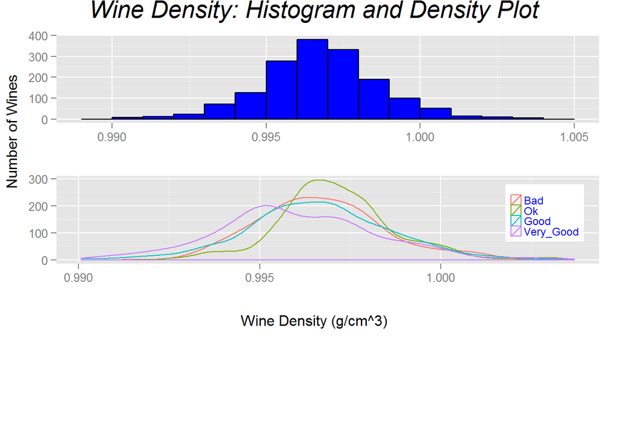

### Description One

The density distribution is very symmetric and appears very normal for a naturally occuring property of wine. The density plot then shows how the wine density distributions differ based on quality.

### Plot Two

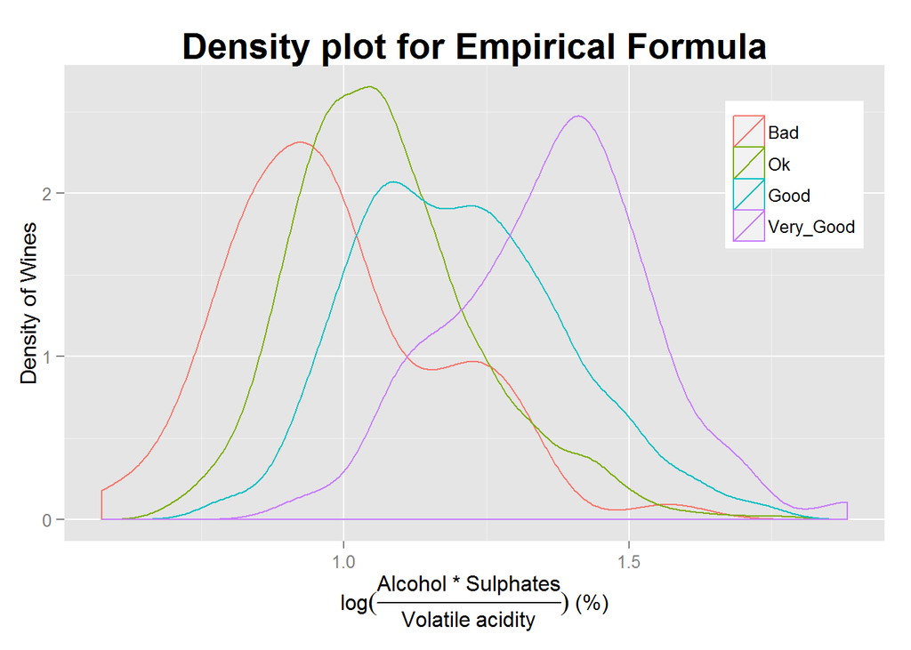

### Description Two

This plot shows how a combination of the variables alcohol, sulphates, and volatile acidity, each well correlated with wine quality can produce a new variable that is even more strongly correlated with quality (correlation coefficient of 0.504). This combination can then better help distinguish wines of differing quality more clearly than any one variable on its own.

### Plot Three

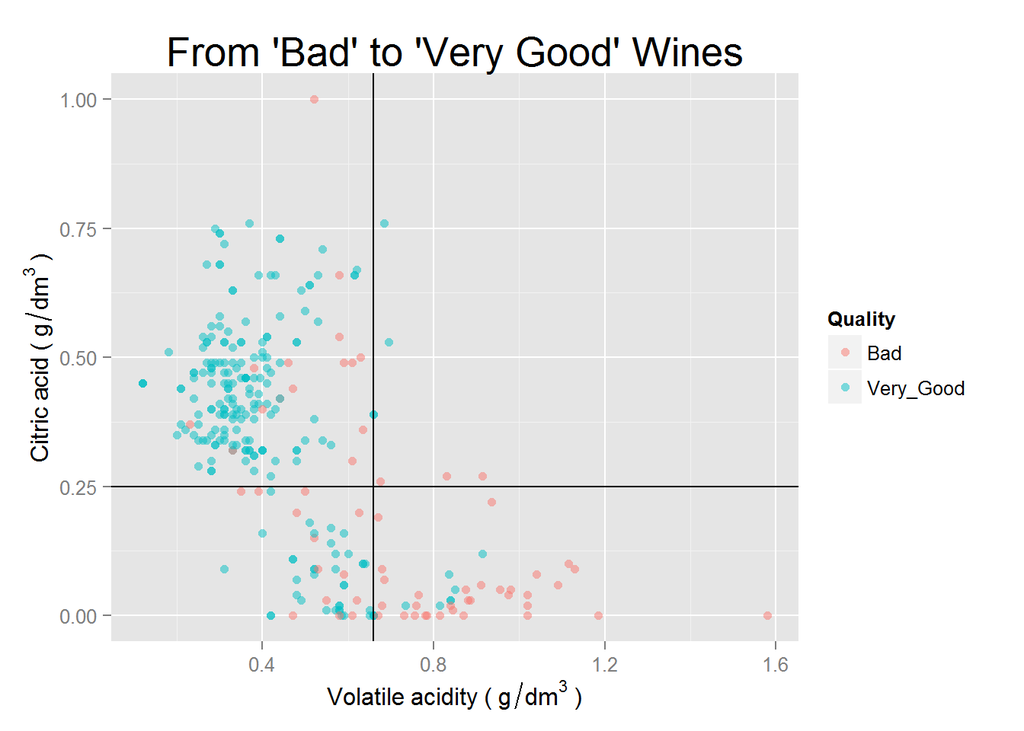

### Description Three

In looking at separating ‘Very Good’ wines from those labeled as ‘Bad’ we can begin to see that some decision boundaries may naturally show up. Here we can see that first splitting wines at a citric acid level of 0.25 will separate the “Very_Good” wines from the “Bad” wines in that branch with an accuracy of 90%. A subsequent boundary at a volatile acidity level below 0.66 allows a classification of wines as “Very_Good” in that branch at an accuracy of 75%. In this way we can build up a decision tree to classify wines. ——

# Reflection

This dataset contained information on 12 different variables for almost 1600 different wines. To me, this dataset showed that their is a great deal to be learned from ‘small’ datasets. I think a systematic approach to exploring first one variable, then two variables, and then multiple variables is a fruitful way to analyze the data. It was fairly clear from the outset that finding variables that correlated well with quality would be of the greatest interest. However, wanting correlations and finding ones that are strong and supported by the data are two different things. The bivariate analysis started to show that many of the variables were correlated with quality and I struggled to find which ones had the strongest relation. It was soon evident that alcohol was the variable most strongly connected to quality but it was a surprise to find out that promising correlations, like citric acid, proved to be relatively unimportant when building a model to predict quality. It was equally surprising to see how a variable like chlorides became important, even though my initial analysis would not have suggested its inclusion. In the end, I was able to build a couple models that gave similar results, which were not that impressive. The two things I would like to be able to do in a future would be to look at a larger dataset that contained a higher percentage of wines classified above 6 and below 5. This, I believe, would be a stronger test of the current model, since about 85% of the current data fell into the two quality ratings of 5 and 6. Another interesting study would be to have the dataset enhanced by including the variety of red wine (merlot, shiraz, etc.) and to create a robust model for all red wines and then explore possible differences by variety.